# Guidelines

```python
import numpy as np
import pandas as pd
import matplotlib.pyplot as plt
import seaborn as sns
```

```python
sns.set()
```

## Q1

Load the data from ‘ex1data1.txt’. The first column is the population of a city and the second column is the profit of a food truck in that city. A negative value for profit indicates a loss

```python
df = pd.read_table('./datasets/ex1data1.txt', sep=",", names=['Population', 'Profit'])
df.head()
```

|  | Population | Profit |
| --- | --- | --- |
| 0 | 6.1101 | 17.5920 |
| 1 | 5.5277 | 9.1302 |
| 2 | 8.5186 | 13.6620 |
| 3 | 7.0032 | 11.8540 |
| 4 | 5.8598 | 6.8233 |

#### a. Visualize the data using the appropriate plot.

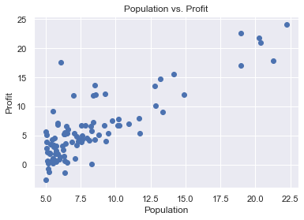

```python
plt.scatter(df.Population, df.Profit)

plt.xlabel('Population')
plt.ylabel('Profit')
plt.title('Population vs. Profit')

plt.show()
```

#### b. Print the description of the data.

```python
df.info()
```

```
<class 'pandas.core.frame.DataFrame'>
RangeIndex: 97 entries, 0 to 96
Data columns (total 2 columns):
 #   Column      Non-Null Count  Dtype
---  ------      --------------  -----
 0   Population  97 non-null     float64
 1   Profit      97 non-null     float64
dtypes: float64(2)
memory usage: 1.6 KB
```

#### c. Check if attributes have a linear relationship, and apply the Linear Regression model. (Train/Test split = 80/20)

```python
X = df.drop(['Profit'], axis=1)
y = df.Profit
```

```python
from sklearn.model_selection import train_test_split
X_train, X_test, y_train, y_test = train_test_split(X, y, test_size=0.2)
```

```python
from sklearn.linear_model import LinearRegression
reg = LinearRegression()
```

```python
reg.fit(X_train, y_train)
```

```
LinearRegression()
```

```python
y_pred = reg.predict(X_test)
```

```python
reg.score(X_test, y_test)
```

```
0.7208154017953732
```

```python
reg.coef_
```

```
array([1.22220802])
```

```python
reg.intercept_
```

```
-4.314934514518108
```

```python
print(f'y = {reg.coef_[0]}x + ({reg.intercept_})')
```

```
y = 1.2222080197692473x + (-4.314934514518108)
```

## Q2

```python
df = pd.read_table('./datasets/ex2data1.txt', sep=",", names=['size', 'bedrooms', 'price'])
df.head()
```

|  | size | bedrooms | price |
| --- | --- | --- | --- |
| 0 | 34.623660 | 78.024693 | 0 |
| 1 | 30.286711 | 43.894998 | 0 |
| 2 | 35.847409 | 72.902198 | 0 |
| 3 | 60.182599 | 86.308552 | 1 |
| 4 | 79.032736 | 75.344376 | 1 |

#### a. Print the description of the data.

```python
df.describe()
```

|  | size | bedrooms | price |
| --- | --- | --- | --- |
| count | 100.000000 | 100.000000 | 100.000000 |
| mean | 65.644274 | 66.221998 | 0.600000 |
| std | 19.458222 | 18.582783 | 0.492366 |
| min | 30.058822 | 30.603263 | 0.000000 |
| 25% | 50.919511 | 48.179205 | 0.000000 |
| 50% | 67.032988 | 67.682381 | 1.000000 |
| 75% | 80.212529 | 79.360605 | 1.000000 |
| max | 99.827858 | 98.869436 | 1.000000 |

#### b. Apply the Linear Regression model. (Train/Test split = 80/20)

```python
X = df.drop(['price'], axis=1)
y = df.price
```

```python
from sklearn.model_selection import train_test_split
X_train, X_test, y_train, y_test = train_test_split(X, y, test_size=0.2, random_state=42)
```

```python
from sklearn.linear_model import LinearRegression
reg = LinearRegression()
```

```python
reg.fit(X_train, y_train)
```

```
LinearRegression()
```

#### c. Find and print the regression parameters.

```python
print(f'y = {reg.coef_[0]} * x1 + {reg.coef_[1]} * x2 + ({reg.intercept_})')
```

```
y = 0.015981513268614855 * x1 + 0.013024853034574952 * x2 + (-1.3283092360466782)
```

#### d. Find the goodness of the model using R2

```python
y_pred = reg.predict(X_test)
```

```python
from sklearn.metrics import r2_score
r2_score(y_test, y_pred)
```

```
0.49507543910358076
```

#### e. Compute MSE for the instances in the test set.

```python
from sklearn.metrics import mean_squared_error
mse = mean_squared_error(y_pred, y_test)
print(mse)
```

```
0.12118189461514065
```

## Q3

Load the data from ‘canada_per_capita_income.csv’. Use this to build a regression model and predict the per capita income for Canadian citizens in the year 2020. Predict Canada’s per capita income in the year 2020. (Expected Output - 41288.69409442)

```python
df = pd.read_csv('./datasets/canada_per_capita_income.csv', names=['year', 'income'])
df.head()
```

|  | year | income |
| --- | --- | --- |
| 0 | 1970 | 3399.299037 |
| 1 | 1971 | 3768.297935 |
| 2 | 1972 | 4251.175484 |
| 3 | 1973 | 4804.463248 |
| 4 | 1974 | 5576.514583 |

```python
X = df.drop(['income'], axis=1)
y = df.income
```

```python
from sklearn.linear_model import LinearRegression
reg = LinearRegression().fit(X, y)
```

```python
reg.predict([[2020]])
```

```
array([41288.69409442])
```

## Q4

Suppose that you are the administrator of a university department and you want to determine each applicant’s chance of admission based on their results on two exams. You have historical data (“ex2data1.txt”) from previous applicants that you can use as a training set for logistic regression. For each training example, you have the applicant’s scores on two exams and the admissions decision. Your task is to build a classification model that estimates an applicant’s probability of admission based the scores from those two exams.

```python
df = pd.read_table('./datasets/ex2data1.txt', names=['a', 'b', 'passed'], sep=',')
df.head()
```

|  | a | b | passed |
| --- | --- | --- | --- |
| 0 | 34.623660 | 78.024693 | 0 |
| 1 | 30.286711 | 43.894998 | 0 |
| 2 | 35.847409 | 72.902198 | 0 |
| 3 | 60.182599 | 86.308552 | 1 |
| 4 | 79.032736 | 75.344376 | 1 |

```python
X = df.drop(['passed'], axis=1)
y = df.passed
```

```python
from sklearn.model_selection import train_test_split
X_train, X_test, y_train, y_test = train_test_split(X, y, test_size=0.2, random_state=42)
```

```python
from sklearn.linear_model import LogisticRegression
log = LogisticRegression()
```

```python
log.fit(X_train, y_train)
```

```
LogisticRegression()
```

```python
log.score(X_test, y_test)
```

```
0.8
```

```python
y_pred = log.predict(X_test)
```

```python
from sklearn.metrics import confusion_matrix
cm = confusion_matrix(y_test, y_pred)
cm
```

```
array([[7, 1],
       [3, 9]], dtype=int64)
```

## Q5

Load the data from ‘HR_comma_sep.csv’. Use this to build a logistic regression model and compute the accuracy of model.

```python
df = pd.read_csv('./datasets/HR_comma_sep.csv')
df.head()
```

|  | satisfaction_level | last_evaluation | number_project | average_montly_hours | time_spend_company | Work_accident | left | promotion_last_5years | Department | salary |
| --- | --- | --- | --- | --- | --- | --- | --- | --- | --- | --- |
| 0 | 0.38 | 0.53 | 2 | 157 | 3 | 0 | 1 | 0 | sales | low |
| 1 | 0.80 | 0.86 | 5 | 262 | 6 | 0 | 1 | 0 | sales | medium |
| 2 | 0.11 | 0.88 | 7 | 272 | 4 | 0 | 1 | 0 | sales | medium |
| 3 | 0.72 | 0.87 | 5 | 223 | 5 | 0 | 1 | 0 | sales | low |
| 4 | 0.37 | 0.52 | 2 | 159 | 3 | 0 | 1 | 0 | sales | low |

```python
from sklearn.preprocessing import LabelEncoder
le = LabelEncoder()
```

```python
for i in ['Department', 'salary']:
    df[i] = le.fit_transform(df[i])

df.head()
```

|  | satisfaction_level | last_evaluation | number_project | average_montly_hours | time_spend_company | Work_accident | left | promotion_last_5years | Department | salary |
| --- | --- | --- | --- | --- | --- | --- | --- | --- | --- | --- |
| 0 | 0.38 | 0.53 | 2 | 157 | 3 | 0 | 1 | 0 | 7 | 1 |
| 1 | 0.80 | 0.86 | 5 | 262 | 6 | 0 | 1 | 0 | 7 | 2 |
| 2 | 0.11 | 0.88 | 7 | 272 | 4 | 0 | 1 | 0 | 7 | 2 |
| 3 | 0.72 | 0.87 | 5 | 223 | 5 | 0 | 1 | 0 | 7 | 1 |
| 4 | 0.37 | 0.52 | 2 | 159 | 3 | 0 | 1 | 0 | 7 | 1 |

```python
X = df.drop(['left'], axis=1)
y = df.left
```

```python
from sklearn.model_selection import train_test_split
X_train, X_test, y_train, y_test = train_test_split(X, y, test_size=0.2, random_state=27)
```

```python
from sklearn.linear_model import LogisticRegression
log = LogisticRegression(max_iter=1000)
```

```python
log.fit(X_train, y_train)
```

```
LogisticRegression(max_iter=1000)
```

```python
log.score(X_test, y_test)
```

```
0.7786666666666666
```

```python
y_pred = log.predict(X_test)
```

```python
from sklearn.metrics import confusion_matrix, ConfusionMatrixDisplay
cm = confusion_matrix(y_pred, y_test)
cm
```

```
array([[2161,  499],
       [ 165,  175]], dtype=int64)
```

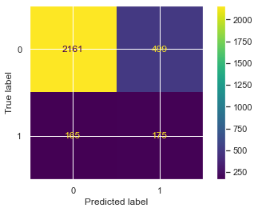

```python
ConfusionMatrixDisplay(cm).plot()
plt.show()
```

## Q6

Load the data from ‘Naive-Bayes-Classification-Data.csv’. Use this to build a Naïve Bayes classifier and compute the accuracy of model.

https://heartbeat.comet.ml/naive-bayes-classifier-in-python-using-scikit-learn13c4deb83bcf

```python
df = pd.read_csv("./heart.csv")
df.head()
```

|  | glucose | bloodpressure | diabetes |
| --- | --- | --- | --- |
| 0 | 40 | 85 | 0 |
| 1 | 40 | 92 | 0 |
| 2 | 45 | 63 | 1 |
| 3 | 45 | 80 | 0 |
| 4 | 40 | 73 | 1 |

```python
X = df.drop('diabetes', axis=1)
y = df.diabetes
```

```python
from sklearn.model_selection import train_test_split
X_train, X_test, y_train, y_test = train_test_split(X, y, test_size=0.2)
```

```python
from sklearn.naive_bayes import GaussianNB
gnb = GaussianNB().fit(X_train, y_train)
```

```python
gnb.score(X_test, y_test)
```

```
0.9396984924623115
```

## Q7

Load Iris data-set. Use this to build a Naïve Bayes classifier and find the accuracy of the model.

```python
from sklearn.datasets import load_iris
iris_data = load_iris()
```

```python
iris_data.keys()
```

```
dict_keys(['data', 'target', 'frame', 'target_names', 'DESCR', 'feature_names', 'filename', 'data_module'])
```

```python
iris = pd.DataFrame(iris_data.data, columns=iris_data.feature_names)
iris['species'] = iris_data.target

iris.head()
```

|  | sepal length (cm) | sepal width (cm) | petal length (cm) | petal width (cm) | species |
| --- | --- | --- | --- | --- | --- |
| 0 | 5.1 | 3.5 | 1.4 | 0.2 | 0 |
| 1 | 4.9 | 3.0 | 1.4 | 0.2 | 0 |
| 2 | 4.7 | 3.2 | 1.3 | 0.2 | 0 |
| 3 | 4.6 | 3.1 | 1.5 | 0.2 | 0 |
| 4 | 5.0 | 3.6 | 1.4 | 0.2 | 0 |

```python
X = iris.drop('species', axis=1)
y = iris.species
```

```python
from sklearn.model_selection import train_test_split
X_train, X_test, y_train, y_test = train_test_split(X, y, test_size=0.2, random_state=1)
```

```python
from sklearn.naive_bayes import GaussianNB
gnb = GaussianNB()
```

```python
gnb.fit(X_train, y_train)
```

```
GaussianNB()
```

```python
gnb.score(X_test, y_test)
```

```
0.9666666666666667
```

```python
y_pred = gnb.predict(X_test)
```

```python
from sklearn.metrics import confusion_matrix, ConfusionMatrixDisplay
cm = confusion_matrix(y_test, y_pred)
cm
```

```
array([[11,  0,  0],
       [ 0, 12,  1],
       [ 0,  0,  6]], dtype=int64)
```

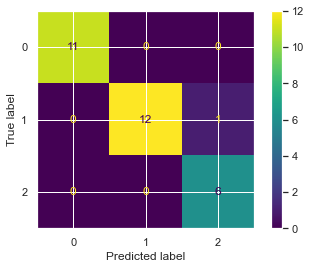

```python
ConfusionMatrixDisplay(cm).plot()
plt.show()
```

## Q9

Load Iris data-set. Use this to build a SVM classifier and find the accuracy of the model.

```python
from sklearn.svm import SVC
svc = SVC()
```

```python
svc.fit(X_train, y_train)
```

```
SVC()
```

```python
svc.score(X_test, y_test)
```

```
0.9666666666666667
```

```python
y_pred = svc.predict(X_test)
```

```python
cm = confusion_matrix(y_test, y_pred)
cm
```

```
array([[11,  0,  0],
       [ 0, 12,  1],
       [ 0,  0,  6]], dtype=int64)
```

[figure not shown]

```python
ConfusionMatrixDisplay(cm).plot()
plt.show()
```

## Q8

Load Breast Cancer Wisconsin (Diagnostic) data-set. Use this to build a SVM classifier and find the accuracy of this model

```python
from sklearn.datasets import load_breast_cancer
cancer_data = load_breast_cancer()
```

```python
df = pd.DataFrame(cancer_data.data, columns = cancer_data.feature_names)
df.head()
```

|  | mean radius | mean texture | mean perimeter | mean area | mean smoothness | mean compactness | mean concavity | mean concave points | mean symmetry | mean fractal dimension | ... | worst radius | worst texture | worst perimeter | worst area | worst smoothness | worst compactness | worst concavity | worst concave points | worst symmetry | worst fractal dimension |
| --- | --- | --- | --- | --- | --- | --- | --- | --- | --- | --- | --- | --- | --- | --- | --- | --- | --- | --- | --- | --- | --- |
| 0 | 17.99 | 10.38 | 122.80 | 1001.0 | 0.11840 | 0.27760 | 0.3001 | 0.14710 | 0.2419 | 0.07871 | ... | 25.38 | 17.33 | 184.60 | 2019.0 | 0.1622 | 0.6656 | 0.7119 | 0.2654 | 0.4601 | 0.11890 |
| 1 | 20.57 | 17.77 | 132.90 | 1326.0 | 0.08474 | 0.07864 | 0.0869 | 0.07017 | 0.1812 | 0.05667 | ... | 24.99 | 23.41 | 158.80 | 1956.0 | 0.1238 | 0.1866 | 0.2416 | 0.1860 | 0.2750 | 0.08902 |
| 2 | 19.69 | 21.25 | 130.00 | 1203.0 | 0.10960 | 0.15990 | 0.1974 | 0.12790 | 0.2069 | 0.05999 | ... | 23.57 | 25.53 | 152.50 | 1709.0 | 0.1444 | 0.4245 | 0.4504 | 0.2430 | 0.3613 | 0.08758 |
| 3 | 11.42 | 20.38 | 77.58 | 386.1 | 0.14250 | 0.28390 | 0.2414 | 0.10520 | 0.2597 | 0.09744 | ... | 14.91 | 26.50 | 98.87 | 567.7 | 0.2098 | 0.8663 | 0.6869 | 0.2575 | 0.6638 | 0.17300 |
| 4 | 20.29 | 14.34 | 135.10 | 1297.0 | 0.10030 | 0.13280 | 0.1980 | 0.10430 | 0.1809 | 0.05883 | ... | 22.54 | 16.67 | 152.20 | 1575.0 | 0.1374 | 0.2050 | 0.4000 | 0.1625 | 0.2364 | 0.07678 |

5 rows × 30 columns

```python
df['type'] = cancer_data.target
```

```python
X = df.drop('type', axis=1)
y = df.type
```

```python
from sklearn.model_selection import train_test_split
X_train, X_test, y_train, y_test = train_test_split(X, y, test_size=0.2)
```

```python
from sklearn.svm import SVC
svc = SVC()
```

```python
svc.fit(X_train, y_train)
```

```
SVC()
```

```python
svc.score(X_test, y_test)
```

```
0.9298245614035088
```

```python
y_pred = svc.predict(X_test)
```

```python
cm = confusion_matrix(y_test, y_pred)
cm
```

```
array([[35,  7],
       [ 1, 71]], dtype=int64)
```

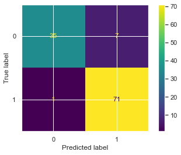

```python
ConfusionMatrixDisplay(cm).plot()
plt.show()
```

## Q10

Load the data from Iris data-set. Use this to build a Decision Tree model and compute the accuracy of the model.

```python
X = iris.drop('species', axis=1)
y = iris.species
```

```python
X_train, X_test, y_train, y_test = train_test_split(X, y, test_size=0.2)
```

```python
from sklearn.tree import DecisionTreeClassifier, plot_tree
dtc = DecisionTreeClassifier()
```

```python
dtc.fit(X_train, y_train)
```

```
DecisionTreeClassifier()
```

```python
dtc.score(X_test, y_test)
```

```
0.8666666666666667
```

```python
y_pred = dtc.predict(X_test)
```

```python
cm = confusion_matrix(y_test, y_pred)
cm
```

```
array([[10,  0,  0],
       [ 0,  6,  1],
       [ 0,  3, 10]], dtype=int64)
```

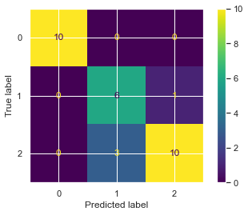

```python
ConfusionMatrixDisplay(cm).plot()
plt.show()
```

```python
fig = plt.figure(figsize=(20, 10))
plot_tree(dtc, filled=True)
plt.show()
```

[output not shown]

## Q11

Load the data from Titanic data-set. Use this to build a Decision Tree model and compute the accuracy.

```python
df = pd.read_csv('./datasets/titanic.csv')
df.head()
```

|  | PassengerId | Name | Pclass | Sex | Age | SibSp | Parch | Ticket | Fare | Cabin | Embarked | Survived |
| --- | --- | --- | --- | --- | --- | --- | --- | --- | --- | --- | --- | --- |
| 0 | 1 | Braund, Mr. Owen Harris | 3 | male | 22.0 | 1 | 0 | A/5 21171 | 7.2500 | NaN | S | 0 |
| 1 | 2 | Cumings, Mrs. John Bradley (Florence Briggs Th... | 1 | female | 38.0 | 1 | 0 | PC 17599 | 71.2833 | C85 | C | 1 |
| 2 | 3 | Heikkinen, Miss. Laina | 3 | female | 26.0 | 0 | 0 | STON/O2. 3101282 | 7.9250 | NaN | S | 1 |
| 3 | 4 | Futrelle, Mrs. Jacques Heath (Lily May Peel) | 1 | female | 35.0 | 1 | 0 | 113803 | 53.1000 | C123 | S | 1 |
| 4 | 5 | Allen, Mr. William Henry | 3 | male | 35.0 | 0 | 0 | 373450 | 8.0500 | NaN | S | 0 |

```python
df.isna().sum()
```

```
PassengerId      0
Name             0
Pclass           0
Sex              0
Age            177
SibSp            0
Parch            0
Ticket           0
Fare             0
Cabin          687
Embarked         2
Survived         0
dtype: int64
```

```python
df.Age.fillna(df.Age.mean(), inplace=True)
df.dropna(subset=['Embarked'], axis=0, inplace=True)
df.drop('Cabin', inplace=True, axis=1)

df.isna().sum()
```

```
PassengerId    0
Name           0
Pclass         0
Sex            0
Age            0
SibSp          0
Parch          0
Ticket         0
Fare           0
Embarked       0
Survived       0
dtype: int64
```

```python
for i in ['Sex', 'Embarked']:
    df[i] = le.fit_transform(df[i])

df.head()
```

|  | PassengerId | Name | Pclass | Sex | Age | SibSp | Parch | Ticket | Fare | Embarked | Survived |
| --- | --- | --- | --- | --- | --- | --- | --- | --- | --- | --- | --- |
| 0 | 1 | Braund, Mr. Owen Harris | 3 | 1 | 22.0 | 1 | 0 | A/5 21171 | 7.2500 | 2 | 0 |
| 1 | 2 | Cumings, Mrs. John Bradley (Florence Briggs Th... | 1 | 0 | 38.0 | 1 | 0 | PC 17599 | 71.2833 | 0 | 1 |
| 2 | 3 | Heikkinen, Miss. Laina | 3 | 0 | 26.0 | 0 | 0 | STON/O2. 3101282 | 7.9250 | 2 | 1 |
| 3 | 4 | Futrelle, Mrs. Jacques Heath (Lily May Peel) | 1 | 0 | 35.0 | 1 | 0 | 113803 | 53.1000 | 2 | 1 |
| 4 | 5 | Allen, Mr. William Henry | 3 | 1 | 35.0 | 0 | 0 | 373450 | 8.0500 | 2 | 0 |

```python
X = df.drop(['PassengerId', 'Name', 'Ticket', 'Survived'], axis=1)
y = df.Survived
```

```python
from sklearn.model_selection import train_test_split
X_train, X_test, y_train, y_test = train_test_split(X, y, test_size=0.2)
```

```python
from sklearn.tree import DecisionTreeClassifier, plot_tree
dtc = DecisionTreeClassifier().fit(X_train, y_train)
```

```python
dtc.score(X_test, y_test)
```

```
0.7415730337078652
```

```python
y_pred = dtc.predict(X_test)
```

```python
from sklearn.metrics import confusion_matrix, ConfusionMatrixDisplay
cm = confusion_matrix(y_test, y_pred)
cm
```

```
array([[83, 26],
       [20, 49]], dtype=int64)
```

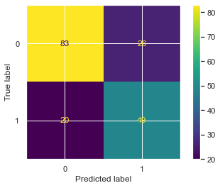

```python
ConfusionMatrixDisplay(cm).plot()
plt.show()
```

## Q12

Load Titanic data-set. Use this to build kNN classifier and compute the accuracy of the model.

```python
from sklearn.neighbors import KNeighborsClassifier
knn = [KNeighborsClassifier(n_neighbors=i).fit(X_train, y_train) for i in range(1, 10)]
```

```python
scores = [knn[i].score(X_test, y_test) for i in range(0, 9)]
scores
```

```
[0.6853932584269663,
 0.6404494382022472,
 0.651685393258427,
 0.6685393258426966,
 0.6460674157303371,
 0.6123595505617978,
 0.6348314606741573,
 0.6460674157303371,
 0.6629213483146067]
```

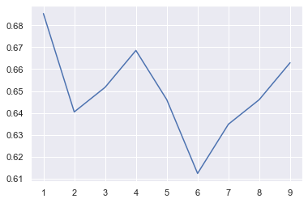

```python
plt.plot(range(1, 10), scores)
plt.show()
```

## Q13

Load Iris data-set. Use this to build kNN classifier and compute the accuracy of model.

```python
X = iris.drop('species', axis=1)
y = iris.species
```

```python
X_train, X_test, y_train, y_test = train_test_split(X, y, test_size=0.2)
```

```python
from sklearn.neighbors import KNeighborsClassifier
knn = KNeighborsClassifier().fit(X_train, y_train)
```

```python
knn.score(X_test, y_test)
```

```
1.0
```

```python
y_pred = knn.predict(X_test)
cm = confusion_matrix(y_test, y_pred)
cm
```

```
array([[10,  0,  0],
       [ 0, 10,  0],
       [ 0,  0, 10]], dtype=int64)
```

## Q14

Load Iris data-set. Perform k-means Clustering over it.

```python
iris.head()
```

|  | sepal length (cm) | sepal width (cm) | petal length (cm) | petal width (cm) | species |
| --- | --- | --- | --- | --- | --- |
| 0 | 5.1 | 3.5 | 1.4 | 0.2 | 0 |
| 1 | 4.9 | 3.0 | 1.4 | 0.2 | 0 |
| 2 | 4.7 | 3.2 | 1.3 | 0.2 | 0 |
| 3 | 4.6 | 3.1 | 1.5 | 0.2 | 0 |
| 4 | 5.0 | 3.6 | 1.4 | 0.2 | 0 |

```python
iris.drop(['petal width (cm)', 'species', 'petal length (cm)'], axis=1, inplace=True)
iris.head()
```

|  | sepal length (cm) | sepal width (cm) |
| --- | --- | --- |
| 0 | 5.1 | 3.5 |
| 1 | 4.9 | 3.0 |
| 2 | 4.7 | 3.2 |
| 3 | 4.6 | 3.1 |
| 4 | 5.0 | 3.6 |

```python
iris.columns = ['len', 'width']
```

```python
from sklearn.cluster import KMeans
kms = KMeans(n_clusters=3)
iris['cluster'] = kms.fit_predict(iris[['len', 'width']])
iris.head()
```

|  | len | width | cluster |
| --- | --- | --- | --- |
| 0 | 5.1 | 3.5 | 1 |
| 1 | 4.9 | 3.0 | 1 |
| 2 | 4.7 | 3.2 | 1 |
| 3 | 4.6 | 3.1 | 1 |
| 4 | 5.0 | 3.6 | 1 |

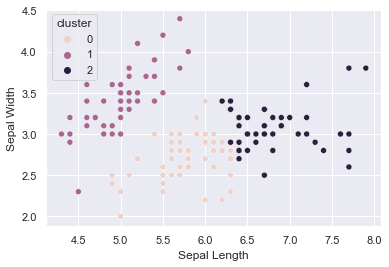

```python
sns.scatterplot(data=iris, x='len', y='width', hue='cluster')
plt.xlabel('Sepal Length')
plt.ylabel('Sepal Width')
plt.show()
```

```python
from sklearn.preprocessing import MinMaxScaler
scaler = MinMaxScaler()
```

```python
for i in ['len', 'width']:
    scaler.fit(iris[[i]])
    iris[i] = scaler.transform(iris[[i]])
```

```python
iris.head()
```

|  | len | width | cluster |
| --- | --- | --- | --- |
| 0 | 0.222222 | 0.625000 | 1 |
| 1 | 0.166667 | 0.416667 | 1 |
| 2 | 0.111111 | 0.500000 | 1 |
| 3 | 0.083333 | 0.458333 | 1 |
| 4 | 0.194444 | 0.666667 | 1 |

```python
iris['clusterM'] = kms.fit_predict(iris[['len', 'width']])
iris.head()
```

|  | len | width | cluster | clusterM |
| --- | --- | --- | --- | --- |
| 0 | 0.222222 | 0.625000 | 1 | 2 |
| 1 | 0.166667 | 0.416667 | 1 | 2 |
| 2 | 0.111111 | 0.500000 | 1 | 2 |
| 3 | 0.083333 | 0.458333 | 1 | 2 |
| 4 | 0.194444 | 0.666667 | 1 | 2 |

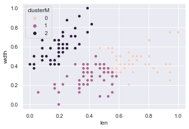

```python
sns.scatterplot(data=iris, x='len', y='width', hue='clusterM')
plt.show()
```

```python
sse = [KMeans(n_clusters=i).fit(iris[['len', 'width']]).inertia_ for i in range(1, 10)]
sse
```

```
[12.797757201646089,
 6.8552905260332775,
 4.115194202754065,
 3.2174838565233785,
 2.5528679699354284,
 2.1069374455642262,
 1.8138603062774203,
 1.5309480258173973,
 1.2688256922081356]
```

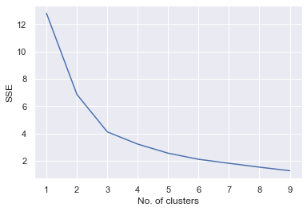

```python
plt.plot(range(1, 10), sse)
plt.xlabel('No. of clusters')
plt.ylabel('SSE')
plt.show()
```

## Playground

```python
df = pd.read_csv('./income.csv')
df.head()
```

|  | Name | Age | Income |
| --- | --- | --- | --- |
| 0 | Rob | 27 | 70000 |
| 1 | Michael | 29 | 90000 |
| 2 | Mohan | 29 | 61000 |
| 3 | Ismail | 28 | 60000 |
| 4 | Kory | 42 | 150000 |

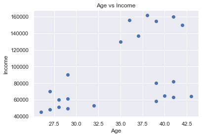

```python
plt.scatter(df.Age, df.Income)
plt.xlabel('Age')
plt.ylabel('Income')
plt.title('Age vs Income')
plt.show()
```

```python
from sklearn.cluster import KMeans
kms = KMeans(n_clusters=3)
y_pred = kms.fit_predict(df[['Age', 'Income']])
y_pred
```

```
array([2, 2, 0, 0, 1, 1, 1, 1, 1, 1, 1, 0, 0, 0, 0, 0, 0, 0, 0, 2, 2, 0])
```

```python
df['cluster'] = y_pred
```

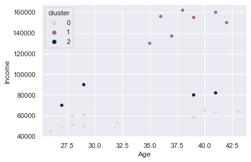

```python
sns.scatterplot(data=df, x='Age', y='Income', hue=df.cluster)
plt.show()
```

```python
from sklearn.preprocessing import MinMaxScaler
scaler = MinMaxScaler()
```

```python
for i in ['Age', 'Income']:
    scaler.fit(df[[i]])
    df[i] = scaler.transform(df[[i]])
```

```python
df.head()
```

|  | Name | Age | Income | cluster |
| --- | --- | --- | --- | --- |
| 0 | Rob | 0.058824 | 0.213675 | 2 |
| 1 | Michael | 0.176471 | 0.384615 | 2 |
| 2 | Mohan | 0.176471 | 0.136752 | 0 |
| 3 | Ismail | 0.117647 | 0.128205 | 0 |
| 4 | Kory | 0.941176 | 0.897436 | 1 |

```python
df['clusterM'] = kms.fit_predict(df[['Age', 'Income']])
df.head()
```

|  | Name | Age | Income | cluster | clusterM |
| --- | --- | --- | --- | --- | --- |
| 0 | Rob | 0.058824 | 0.213675 | 2 | 1 |
| 1 | Michael | 0.176471 | 0.384615 | 2 | 1 |
| 2 | Mohan | 0.176471 | 0.136752 | 0 | 1 |
| 3 | Ismail | 0.117647 | 0.128205 | 0 | 1 |
| 4 | Kory | 0.941176 | 0.897436 | 1 | 0 |

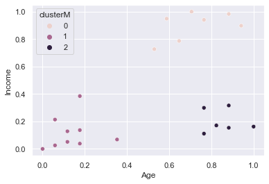

```python
sns.scatterplot(data=df, x='Age', y='Income', hue='clusterM')
plt.show()
```

```python
sse = [KMeans(n_clusters=i).fit(df[['Age', 'Income']]).inertia_ for i in range(1, 10)]
sse
```

```
[5.434011511988179,
 2.091136388699078,
 0.4750783498553096,
 0.34910470944195654,
 0.2798062931046179,
 0.2203764169077067,
 0.1685851223602976,
 0.13762504146528043,
 0.10740235405674736]
```

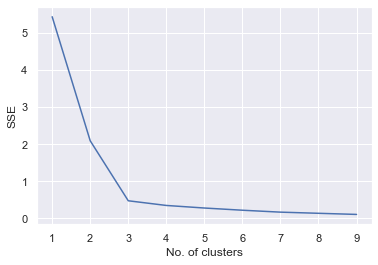

```python
plt.plot(range(1, 10), sse)
plt.ylabel('SSE')
plt.xlabel('No. of clusters')
plt.show()
```